# Juan Reyes, Ilya Schneider, Francesco de Luca

## Introduction

U.S. poverty rates was 12.8% in 2021, almost a 2% increase from the pre-pandemic poverty levels. The increases in the national poverty rate over the last two years reversed a trend of five consecutive annual declines. Having the ability to predict if an individual in the US is likely to be in poverty can be incredibly useful to inform public policy-making. By understanding which characteristics are likely to lead to these outcomes, policymakers may be able to more effectively implement targeted poverty reduction polices and once again reverse this trend.

## Data sources

The project’s public GitHub repository can be seen [here](https://github.com/ilyaschneider/670_final_project).

Next we load the necessary libraries and read in the data:

```r
library(tidyverse)
library(dplyr)
library(ipumsr)
library(janitor)
library(srvyr)
library(parsnip)
library(survey)
library(tidymodels)
library(patchwork)
library(rpart.plot)
library(lubridate)
library(themis)
library(tune)
library(tigris)
library(randomForest)
library(ranger)
library(glmnet)
library(labelled)
library(haven)
```

```r
ddi <- read_ipums_ddi("cps_00010.xml")
data <- read_ipums_micro(ddi)
data <- clean_names(data)
```

First we drop extraneous variables, remove multi-state FIPS codes, and recode missing or unavailable data into NAs. We also recode categorical variables into dummy variables and create a dummy variable for immigration status, coded as 1 for people born in the U.S. and 0 for people born in U.S. outlying territories, naturalized citizens, non-citizens, and people born abroad to American parents. We then create the weighted data frame that we will use throughout our analysis.

```r
cps_svy <- data %>%

  #Remove unnecessary variables
  select(-asecflag, -serial, -month, -cpsid, -cpsidp, -pernum, -asecwth, -himcaidly) %>%

  #Remove multi-state FIPS codes
  filter(statefip <= 56) %>%

  #Recode missing or otherwise unavailabe data into NAs
  mutate_at(vars(statefip, offpov), list(~ case_when(. == 99 ~ NA_real_, TRUE ~ as.numeric(.)))) %>%
  mutate_at(vars(county, pubhous, ownershp, empstat, labforce, diffany, workly, poverty, himcarely, phinsur, kidcneed, union, yrimmig, foodstmp, stampval, occ, ind, occly, indly, nchlt5, nchild, famsize, age, stampmo), list(~ case_when( . == 0 ~ NA_real_, TRUE ~ as.numeric(.)))) %>%
  mutate_at(vars(metro, migrate1, vetstat), list(~ case_when(. == 0 | . == 9 ~ NA_real_, TRUE ~ as.numeric(.)))) %>%
  mutate(hhincome = case_when(hhincome == 99999999 ~ NA_real_, TRUE ~ as.numeric(hhincome))) %>%
  mutate_at(vars(citizen, marst, sex), list(~ case_when(. == 9 ~ NA_real_, TRUE ~ as.numeric(.)))) %>%
  mutate_at(vars(classwkr, classwly), list(~ case_when(. == 0 | . == 99 ~ NA_real_, TRUE ~ as.numeric(.)))) %>%
  mutate(hispan = case_when(hispan == 901 | hispan == 902 ~ NA_real_, TRUE ~ as.numeric(hispan))) %>%
  mutate(uhrsworkt = case_when(uhrsworkt == 997 | uhrsworkt == 999 ~ NA_real_, TRUE ~ as.numeric(uhrsworkt))) %>%
  mutate(educ = case_when(educ == 001 | educ == 999 ~ NA_real_, TRUE ~ as.numeric(educ))) %>%
  mutate(incss = case_when(incss == 999999 ~ NA_real_, TRUE ~ as.numeric(incss))) %>%
  mutate(incfarm = case_when(incfarm == 99999999 | incfarm == 99999998 ~ NA_real_, TRUE ~ as.numeric(incfarm))) %>%
  mutate(incint = case_when(incint == 9999999 ~ NA_real_, TRUE ~ as.numeric(incint))) %>%
  mutate(bpl = case_when(bpl == 96000 | bpl == 99999 ~ NA_real_, TRUE ~ as.numeric(bpl))) %>%
  mutate(race = case_when(race == 999 ~ NA_real_, TRUE ~ as.numeric(race))) %>%

  #Create dummy variable for immigration status:
  mutate(immigrant = case_when(citizen == 1 ~ 0, citizen != 1 ~ 1, TRUE ~ NA_real_)) %>%

  #Recode variables as dummies:
  mutate_at(vars(pubhous, foodstmp, sex, vetstat, labforce, diffany, himcarely, phinsur, anycovnw, kidcneed, workly), list(~ case_when(
    . == 2 ~ 1,
    . == 1 ~ 0,
    TRUE ~ NA_real_))) %>%

  #Recode poverty in reverse, since we want 1 to be those in poverty:
  mutate_at(vars(offpov), list(~ case_when(
    . == 01 ~ 1,
    . == 02 ~ 0,
    TRUE ~ NA_real_)))

#Weight the data as a survey using individual weights
weighted_cps <- as_survey_design(cps_svy, weights = asecwt)

#Create tibbles by year to use in model construction
weighted_cps_2018 <- as.data.frame(weighted_cps) %>%
  filter(year == 2018)
weighted_cps_2019 <- as.data.frame(weighted_cps) %>%
  filter(year == 2019)
```

IPUMS uses two different measures of poverty, namely `offpov` and `poverty`. The former is used to calculate official poverty rates, correcting for errors in the `poverty` variable by including those only in the poverty universe. The documentation explains that “If one restricts the poverty universe correctly, POVERTY will replicate official poverty rates for most years except for survey years 2000, 1993, 1987-1975 and 1970.” Is there considerable difference in the data between how these two variables measure poverty rates between the years?

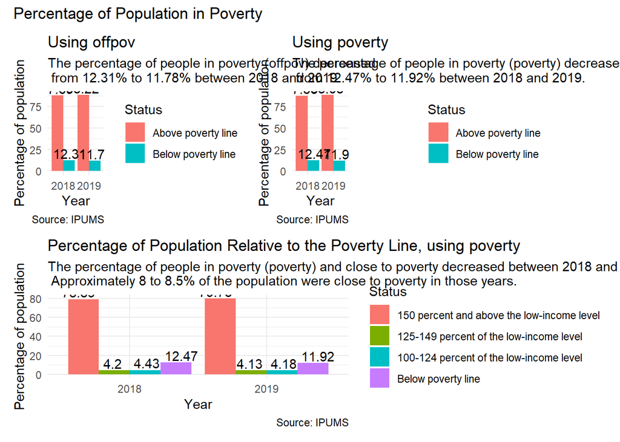

```r
#Creating bar charts to see the difference between "offpov" and "poverty" in the data

offpov_bar <- weighted_cps %>%
  drop_na(offpov) %>%
  select(year, offpov) %>%
  group_by(year, offpov) %>%
  summarize(prop = survey_prop()*100) %>%
  ggplot(aes(x = factor(year), y = prop, fill = factor(offpov))) +
  geom_col(position = "dodge") +
  geom_text(aes(label = round(prop, 2)),
            position = position_dodge(width = 1),
            color="black", vjust = -.2, hjust = .5) +
  labs(
    title = "Using offpov",
    subtitle = "The percentage of people in poverty (offpov) decreased \n from 12.31% to 11.78% between 2018 and 2019.",
    caption = "Source: IPUMS",
    x = "Year",
    y = "Percentage of population",
    fill = "Status"
  ) +
  scale_fill_hue(labels = c("Above poverty line", "Below poverty line")) +
  theme(legend.title = element_blank()) +
  theme_minimal()


poverty_bar_clean <- weighted_cps %>%
  drop_na(poverty) %>%
  #Make poverty a binary indicator
  mutate(poverty = case_when(poverty == 10 ~ 1, poverty >= 20 ~ 0)) %>%
  select(year, poverty) %>%
  group_by(year, poverty) %>%
  summarize(prop = survey_prop()*100) %>%
  ggplot(aes(x = factor(year), y = prop, fill = factor(poverty))) +
  geom_col(position = "dodge") +
  geom_text(aes(label = round(prop, 2)),
            position = position_dodge(width = 1),
            color="black", vjust = -.2, hjust = .5) +
  labs(
    title = "Using poverty",
    subtitle = "The percentage of people in poverty (poverty) decreased \n from 12.47% to 11.92% between 2018 and 2019.",
    caption = "Source: IPUMS",
    x = "Year",
    y = "Percentage of population",
    fill = "Status"
  ) +
  scale_fill_hue(labels = c("Above poverty line", "Below poverty line")) +
  theme(legend.title = element_blank()) +
  theme_minimal()


poverty_bar_detail <- weighted_cps %>%
  drop_na(poverty) %>%
  #Reverse the categories
  mutate(poverty = case_when(
    poverty == 10 ~ 3,
    poverty == 21 ~ 2,
    poverty == 22 ~ 1,
    poverty == 23 ~ 0
  )) %>%
  select(year, poverty) %>%
  group_by(year, poverty) %>%
  summarize(prop = survey_prop()*100) %>%
  ggplot(aes(x = factor(year), y = prop, fill = factor(poverty))) +
  geom_col(position = "dodge") +
  geom_text(aes(label = round(prop, 2)),
            position = position_dodge(width = 1),
            color="black", vjust = -.2) +
  labs(
    title = "Percentage of Population Relative to the Poverty Line, using poverty",
    subtitle = "The percentage of people in poverty (poverty) and close to poverty decreased between 2018 and 2019. \n Approximately 8 to 8.5% of the population were close to poverty in those years.",
    caption = "Source: IPUMS",
    x = "Year",
    y = "Percentage of population",
    fill = "Status"
  ) +
  scale_fill_hue(labels = c("150 percent and above the low-income level", "125-149 percent of the low-income level", "100-124 percent of the low-income level", "Below poverty line")) +
  theme(legend.title = element_blank()) +
  theme_minimal()


((offpov_bar + poverty_bar_clean ) / poverty_bar_detail) + plot_annotation(title = 'Percentage of Population in Poverty')
```

As the bar-charts above show, there is a very minor difference in poverty rates between `offpov` and `poverty`. In both 2018 and 2019, the difference in poverty rate was less than 0.25 percentage points in magnitude between the two variables. We can conclude that these two variables are very similar. That being said, the poverty levels remained relatively constant between 2018 and 2019, as no major disruptions in the economic markets were occurring at the time. Since no major differences are visible, we will use `offpov` as our primary outcome variable.